# Chapter 3 — Building and Preparing Datasets for Energetic Materials

### Python Code Examples · Jupyter Notebook Edition

**Finding, cleaning, and organising your data**

[output not shown]

> **Run each cell in order — Shift+Enter.**

## Block 0 · Install & Shared Dataset

Run once. Creates the shared literature dataset used in all later blocks.

```python
# Uncomment to install on first run
# !pip install rdkit mordred pandas matplotlib seaborn scikit-learn

import re, math, warnings
warnings.filterwarnings('ignore')

import numpy  as np
import pandas as pd
import matplotlib.pyplot as plt
import seaborn as sns

from rdkit import Chem, DataStructs
from rdkit.Chem import Descriptors, rdMolDescriptors, AllChem, MolToSmiles, MolFromSmiles
from rdkit.Chem.Scaffolds import MurckoScaffold
from rdkit.Chem import rdFingerprintGenerator

from sklearn.model_selection import train_test_split
from sklearn.preprocessing   import StandardScaler, MinMaxScaler
from sklearn.feature_selection import VarianceThreshold
from sklearn.impute           import SimpleImputer

from IPython.display import display, HTML
%matplotlib inline
plt.rcParams['figure.dpi'] = 120

# ── Literature dataset: 30 energetic compounds ─────────────────
# Columns: name, SMILES, formula, MW, density(g/cc),
#          impact_sens(J), decomp_temp(C), det_velocity(m/s),
#          heat_formation(kJ/mol), class
# Sources: Cooper 1996, Dobratz 1981, Zeman 2003, open literature

RAW_DATA = [
    # name,         SMILES,                                                              formula,      MW,     rho,   IS,    Td,   Dv,    Hf,    cls
    ['TNT',        'Cc1c([N+](=O)[O-])cc([N+](=O)[O-])cc1[N+](=O)[O-]',              'C7H5N3O6',  227.13, 1.654,  15.0, 300,  6900,  -54.4, 'Secondary'],
    ['RDX',        'O=[N+]([O-])N1CN([N+](=O)[O-])CN([N+](=O)[O-])C1',               'C3H6N6O6',  222.12, 1.820,   7.4, 210,  8750,   86.3, 'Secondary'],
    ['HMX',        'O=[N+]([O-])N1CN([N+](=O)[O-])CN([N+](=O)[O-])CN([N+](=O)[O-])C1','C4H8N8O8', 296.16, 1.905,   7.4, 280,  9110,   75.0, 'Secondary'],
    ['PETN',       'C(CO[N+](=O)[O-])(CO[N+](=O)[O-])(CO[N+](=O)[O-])CO[N+](=O)[O-]','C5H8N4O12',316.14, 1.778,   3.0, 160,  8400,  -538.5,'Secondary'],
    ['TATB',       'Nc1c([N+](=O)[O-])c(N)c([N+](=O)[O-])c(N)c1[N+](=O)[O-]',        'C6H6N6O6', 258.15, 1.939,  50.0, 360,  7350,  -139.7,'Insensitive'],
    ['NTO',        'O=[N+]([O-])c1n[nH]c(=O)[nH]1',                                  'C2H2N4O3',  130.06, 1.930,  71.0, 273,  8000,   -91.7,'Insensitive'],
    ['FOX-7',      'NC(=C([N+](=O)[O-])[N+](=O)[O-])N',                               'C2H4N4O4',  148.08, 1.885,  25.0, 230,  8870,  -133.8,'Insensitive'],
    ['DNAN',       'COc1ccc([N+](=O)[O-])cc1[N+](=O)[O-]',                            'C7H6N2O5',  198.13, 1.321,  40.0, 190,  6900,  -182.7,'Insensitive'],
    ['CL-20',      'O=[N+]([O-])N1CN2CN([N+](=O)[O-])CN1[N+](=O)[O-]',               'C6H6N12O12',438.19, 2.044,   4.0, 230,  9400,   460.0,'Secondary'],
    ['Tetryl',     'CN([N+](=O)[O-])c1c([N+](=O)[O-])cc([N+](=O)[O-])cc1[N+](=O)[O-]','C7H5N5O8', 287.14, 1.730,   3.0, 195,  7850,   18.9, 'Secondary'],
    ['TNAZ',       'O=[N+]([O-])C1(CN([N+](=O)[O-])C1[N+](=O)[O-])[N+](=O)[O-]',    'C3H4N4O8',  240.08, 1.840,  12.0, 200,  8740,   17.0, 'Secondary'],
    ['LLM-105',    'Nc1nc2c([N+](=O)[O-])n[nH]c2c([N+](=O)[O-])n1',                  'C4H4N8O4',  228.12, 1.913,  40.0, 328,  8560,   135.6,'Insensitive'],
    ['ANTA',       'Nc1nnc([N+](=O)[O-])[nH]1',                                       'C2H3N5O2',  129.08, 1.840,  60.0, 260,  8200,    28.0,'Insensitive'],
    ['Nitroguanidine','NC(=N)N[N+](=O)[O-]',                                          'CH4N4O2',   104.07, 1.770,  95.0, 250,  7900,   -92.5,'Insensitive'],
    ['BTNEU',      'O=[N+]([O-])c1c([N+](=O)[O-])c([N+](=O)[O-])c([N+](=O)[O-])c([N+](=O)[O-])c1[N+](=O)[O-]','C6N6O12',348.10,1.980,  8.0, 230,  9000,   385.0,'Secondary'],
    ['Picric acid', 'Oc1c([N+](=O)[O-])cc([N+](=O)[O-])cc1[N+](=O)[O-]',             'C6H3N3O7',  229.10, 1.763,   7.4, 300,  7350,  -217.8,'Secondary'],
    ['DATB',       'Nc1c([N+](=O)[O-])c(N)c([N+](=O)[O-])cc1[N+](=O)[O-]',           'C6H5N5O6',  243.13, 1.840,  50.0, 320,  7520,  -143.5,'Insensitive'],
    ['NONA',       'O=[N+]([O-])c1c([N+](=O)[O-])c([N+](=O)[O-])c([N+](=O)[O-])c([N+](=O)[O-])c1[N+](=O)[O-]','C6HN5O10',287.10,1.870, 6.0, 220,  8700,   300.0,'Secondary'],
    ['BTF',        'O=[N+]([O-])c1c([N+](=O)[O-])c([N+](=O)[O-])c([N+](=O)[O-])c([N+](=O)[O-])n1[N+](=O)[O-]','C5N6O12',334.10,1.920,  5.0, 210,  8900,   420.0,'Secondary'],
    ['AN',         'N.[N+](=O)([O-])[O-]',                                            'H4N2O3',     80.04, 1.720, 100.0, 230,  4500,  -365.6,'Propellant'],
    ['AP',         '[NH4+].[O-]Cl(=O)(=O)=O',                                         'ClH4NO4',   117.49, 1.950, 110.0, 300,  5500,  -295.8,'Propellant'],
    ['NC13',       'OCC1OC(OC2C(COC(=O)[N+](=O)[O-])OC(OC3C(COC(=O)[N+](=O)[O-])OC(O)C(COC(=O)[N+](=O)[O-])C3OC(=O)[N+](=O)[O-])C(OC(=O)[N+](=O)[O-])C2OC(=O)[N+](=O)[O-])C(OC(=O)[N+](=O)[O-])C1OC(=O)[N+](=O)[O-]','C12H14N7O27',609.21,1.660, 30.0, 180, 7300, -618.0,'Propellant'],
    ['NG',         'O[C@@H](CO[N+](=O)[O-])CO[N+](=O)[O-]',                           'C3H5N3O9',  227.09, 1.591,  0.2, 200,  7700, -370.9,'Secondary'],
    ['EDNA',       'O=[N+]([O-])NCC[N+](=O)[O-]',                                     'C2H5N3O4',  135.08, 1.713,  5.0, 175,  7570,  -148.0,'Secondary'],
    ['Heptyl',     'CC(C)(C)c1c([N+](=O)[O-])cc([N+](=O)[O-])cc1[N+](=O)[O-]',       'C10H11N3O6',269.21, 1.490,  20.0, 190,  6800,  -136.0,'Secondary'],
    ['TETNB',      'O=[N+]([O-])c1c([N+](=O)[O-])c([N+](=O)[O-])cc([N+](=O)[O-])c1', 'C6H2N4O8',  258.10, 1.814,  8.0, 180,  7900,   125.0,'Secondary'],
    ['MHN',        'OC(CO[N+](=O)[O-])CO[N+](=O)[O-]',                                'C3H6N2O7',  182.09, 1.450,  60.0, 175,  6500,  -403.0,'Secondary'],
    ['NQ',         'NC(=N)N[N+](=O)[O-]',                                             'CH4N4O2',   104.07, 1.710, None, 245,  7870,   -96.0,'Insensitive'],  # IS missing
    ['HNS',        'O=[N+]([O-])c1ccc(C=Cc2ccc([N+](=O)[O-])cc2[N+](=O)[O-])c([N+](=O)[O-])c1','C14H6N6O12',450.22,1.745,  7.0, 318, 7600,   22.5,'Secondary'],
    ['DNAZ',       'O=[N+]([O-])N1CC([N+](=O)[O-])C1',                                'C3H5N3O4',  147.09, 1.699,  14.0, 155,  7550,  None,  'Secondary'],  # Hf missing
]

COLS = ['Name','SMILES','Formula','MW','Density','ImpactSens_J',
        'DecompTemp_C','DetVel_ms','HeatForm_kJmol','Class']

df_raw = pd.DataFrame(RAW_DATA, columns=COLS)

print(f'Dataset loaded: {df_raw.shape[0]} compounds × {df_raw.shape[1]} columns')
print(f'Classes: {df_raw["Class"].value_counts().to_dict()}')
"""
display(df_raw.head(6).style.hide(axis='index')
        .set_caption('Raw Literature Dataset (first 6 rows)')
        .set_table_styles([{'selector':'caption',
                            'props':[('font-size','14px'),('font-weight','bold')]}]))
"""

display(df_raw)
```

```
Dataset loaded: 30 compounds × 10 columns
Classes: {'Secondary': 18, 'Insensitive': 9, 'Propellant': 3}
```

|  | Name | SMILES | Formula | MW | Density | ImpactSens_J | DecompTemp_C | DetVel_ms | HeatForm_kJmol | Class |
| --- | --- | --- | --- | --- | --- | --- | --- | --- | --- | --- |
| 0 | TNT | Cc1c([N+](=O)[O-])cc([N+](=O)[O-])cc1[N+](=O)[O-] | C7H5N3O6 | 227.13 | 1.654 | 15.0 | 300 | 6900 | -54.4 | Secondary |
| 1 | RDX | O=[N+]([O-])N1CN([N+](=O)[O-])CN([N+](=O)[O-])C1 | C3H6N6O6 | 222.12 | 1.820 | 7.4 | 210 | 8750 | 86.3 | Secondary |
| 2 | HMX | O=[N+]([O-])N1CN([N+](=O)[O-])CN([N+](=O)[O-])... | C4H8N8O8 | 296.16 | 1.905 | 7.4 | 280 | 9110 | 75.0 | Secondary |
| 3 | PETN | C(CO[N+](=O)[O-])(CO[N+](=O)[O-])(CO[N+](=O)[O... | C5H8N4O12 | 316.14 | 1.778 | 3.0 | 160 | 8400 | -538.5 | Secondary |
| 4 | TATB | Nc1c([N+](=O)[O-])c(N)c([N+](=O)[O-])c(N)c1[N+... | C6H6N6O6 | 258.15 | 1.939 | 50.0 | 360 | 7350 | -139.7 | Insensitive |
| 5 | NTO | O=[N+]([O-])c1n[nH]c(=O)[nH]1 | C2H2N4O3 | 130.06 | 1.930 | 71.0 | 273 | 8000 | -91.7 | Insensitive |
| 6 | FOX-7 | NC(=C([N+](=O)[O-])[N+](=O)[O-])N | C2H4N4O4 | 148.08 | 1.885 | 25.0 | 230 | 8870 | -133.8 | Insensitive |
| 7 | DNAN | COc1ccc([N+](=O)[O-])cc1[N+](=O)[O-] | C7H6N2O5 | 198.13 | 1.321 | 40.0 | 190 | 6900 | -182.7 | Insensitive |
| 8 | CL-20 | O=[N+]([O-])N1CN2CN([N+](=O)[O-])CN1[N+](=O)[O-] | C6H6N12O12 | 438.19 | 2.044 | 4.0 | 230 | 9400 | 460.0 | Secondary |
| 9 | Tetryl | CN([N+](=O)[O-])c1c([N+](=O)[O-])cc([N+](=O)[O... | C7H5N5O8 | 287.14 | 1.730 | 3.0 | 195 | 7850 | 18.9 | Secondary |
| 10 | TNAZ | O=[N+]([O-])C1(CN([N+](=O)[O-])C1[N+](=O)[O-])... | C3H4N4O8 | 240.08 | 1.840 | 12.0 | 200 | 8740 | 17.0 | Secondary |
| 11 | LLM-105 | Nc1nc2c([N+](=O)[O-])n[nH]c2c([N+](=O)[O-])n1 | C4H4N8O4 | 228.12 | 1.913 | 40.0 | 328 | 8560 | 135.6 | Insensitive |
| 12 | ANTA | Nc1nnc([N+](=O)[O-])[nH]1 | C2H3N5O2 | 129.08 | 1.840 | 60.0 | 260 | 8200 | 28.0 | Insensitive |
| 13 | Nitroguanidine | NC(=N)N[N+](=O)[O-] | CH4N4O2 | 104.07 | 1.770 | 95.0 | 250 | 7900 | -92.5 | Insensitive |
| 14 | BTNEU | O=[N+]([O-])c1c([N+](=O)[O-])c([N+](=O)[O-])c(... | C6N6O12 | 348.10 | 1.980 | 8.0 | 230 | 9000 | 385.0 | Secondary |
| 15 | Picric acid | Oc1c([N+](=O)[O-])cc([N+](=O)[O-])cc1[N+](=O)[O-] | C6H3N3O7 | 229.10 | 1.763 | 7.4 | 300 | 7350 | -217.8 | Secondary |
| 16 | DATB | Nc1c([N+](=O)[O-])c(N)c([N+](=O)[O-])cc1[N+](=... | C6H5N5O6 | 243.13 | 1.840 | 50.0 | 320 | 7520 | -143.5 | Insensitive |
| 17 | NONA | O=[N+]([O-])c1c([N+](=O)[O-])c([N+](=O)[O-])c(... | C6HN5O10 | 287.10 | 1.870 | 6.0 | 220 | 8700 | 300.0 | Secondary |
| 18 | BTF | O=[N+]([O-])c1c([N+](=O)[O-])c([N+](=O)[O-])c(... | C5N6O12 | 334.10 | 1.920 | 5.0 | 210 | 8900 | 420.0 | Secondary |
| 19 | AN | N.[N+](=O)([O-])[O-] | H4N2O3 | 80.04 | 1.720 | 100.0 | 230 | 4500 | -365.6 | Propellant |
| 20 | AP | [NH4+].[O-]Cl(=O)(=O)=O | ClH4NO4 | 117.49 | 1.950 | 110.0 | 300 | 5500 | -295.8 | Propellant |
| 21 | NC13 | OCC1OC(OC2C(COC(=O)[N+](=O)[O-])OC(OC3C(COC(=O... | C12H14N7O27 | 609.21 | 1.660 | 30.0 | 180 | 7300 | -618.0 | Propellant |
| 22 | NG | O[C@@H](CO[N+](=O)[O-])CO[N+](=O)[O-] | C3H5N3O9 | 227.09 | 1.591 | 0.2 | 200 | 7700 | -370.9 | Secondary |
| 23 | EDNA | O=[N+]([O-])NCC[N+](=O)[O-] | C2H5N3O4 | 135.08 | 1.713 | 5.0 | 175 | 7570 | -148.0 | Secondary |
| 24 | Heptyl | CC(C)(C)c1c([N+](=O)[O-])cc([N+](=O)[O-])cc1[N... | C10H11N3O6 | 269.21 | 1.490 | 20.0 | 190 | 6800 | -136.0 | Secondary |
| 25 | TETNB | O=[N+]([O-])c1c([N+](=O)[O-])c([N+](=O)[O-])cc... | C6H2N4O8 | 258.10 | 1.814 | 8.0 | 180 | 7900 | 125.0 | Secondary |
| 26 | MHN | OC(CO[N+](=O)[O-])CO[N+](=O)[O-] | C3H6N2O7 | 182.09 | 1.450 | 60.0 | 175 | 6500 | -403.0 | Secondary |
| 27 | NQ | NC(=N)N[N+](=O)[O-] | CH4N4O2 | 104.07 | 1.710 | NaN | 245 | 7870 | -96.0 | Insensitive |
| 28 | HNS | O=[N+]([O-])c1ccc(C=Cc2ccc([N+](=O)[O-])cc2[N+... | C14H6N6O12 | 450.22 | 1.745 | 7.0 | 318 | 7600 | 22.5 | Secondary |
| 29 | DNAZ | O=[N+]([O-])N1CC([N+](=O)[O-])C1 | C3H5N3O4 | 147.09 | 1.699 | 14.0 | 155 | 7550 | NaN | Secondary |

## Block 1 · Literature Data Quality Audit

Before doing anything else, **audit your data**:

- How many records do you have per property?
- Which properties have the most missing values?
- Are units consistent?
- What is the class distribution?

A data audit tells you where to focus cleaning effort.

```python
# ── 1a: Missing value audit ────────────────────────────────────

numeric_cols = ['MW','Density','ImpactSens_J','DecompTemp_C',
                'DetVel_ms','HeatForm_kJmol']

# Convert to numeric (coerce bad values to NaN)
df = df_raw.copy()
for col in numeric_cols:
    df[col] = pd.to_numeric(df[col], errors='coerce')

# Missing value summary
missing = pd.DataFrame({
    'Total':   df[numeric_cols].shape[0],
    'Missing': df[numeric_cols].isna().sum(),
    'Present': df[numeric_cols].notna().sum(),
    'Missing%': (df[numeric_cols].isna().mean() * 100).round(1),
}).reset_index().rename(columns={'index': 'Property'})

"""
display(missing.style
        .background_gradient(subset=['Missing%'], cmap='Reds')
        .hide(axis='index')
        .set_caption('Missing Value Audit')
        .set_table_styles([{'selector':'caption',
                            'props':[('font-size','14px'),('font-weight','bold')]}]))
"""
display(missing)
```

|  | Property | Total | Missing | Present | Missing% |
| --- | --- | --- | --- | --- | --- |
| 0 | MW | 30 | 0 | 30 | 0.0 |
| 1 | Density | 30 | 0 | 30 | 0.0 |
| 2 | ImpactSens_J | 30 | 1 | 29 | 3.3 |
| 3 | DecompTemp_C | 30 | 0 | 30 | 0.0 |
| 4 | DetVel_ms | 30 | 0 | 30 | 0.0 |
| 5 | HeatForm_kJmol | 30 | 1 | 29 | 3.3 |

```python
# ── 1b: Basic descriptive statistics per property ──────────────

stats = df[numeric_cols].describe().T
stats['range'] = stats['max'] - stats['min']
stats['cv%']   = (stats['std'] / stats['mean'] * 100).round(1)  # coefficient of variation
display(stats[['count','mean','std','min','max','range','cv%']])
"""
display(stats[['count','mean','std','min','max','range','cv%']]
        .style.format('{:.2f}')
        .background_gradient(subset=['cv%'], cmap='Blues')
        .set_caption('Descriptive Statistics (cv% = coefficient of variation)')
        .set_table_styles([{'selector':'caption',
                            'props':[('font-size','14px'),('font-weight','bold')]}]))
"""
```

|  | count | mean | std | min | max | range | cv% |
| --- | --- | --- | --- | --- | --- | --- | --- |
| MW | 30.0 | 241.462333 | 116.148562 | 80.040 | 609.210 | 529.170 | 48.1 |
| Density | 30.0 | 1.776133 | 0.162403 | 1.321 | 2.044 | 0.723 | 9.1 |
| ImpactSens_J | 29.0 | 29.772414 | 32.077929 | 0.200 | 110.000 | 109.800 | 107.7 |
| DecompTemp_C | 30.0 | 236.466667 | 55.822214 | 155.000 | 360.000 | 205.000 | 23.6 |
| DetVel_ms | 30.0 | 7773.000000 | 1069.950531 | 4500.000 | 9400.000 | 4900.000 | 13.8 |
| HeatForm_kJmol | 29.0 | -67.400000 | 263.555154 | -618.000 | 460.000 | 1078.000 | -391.0 |

[output not shown]

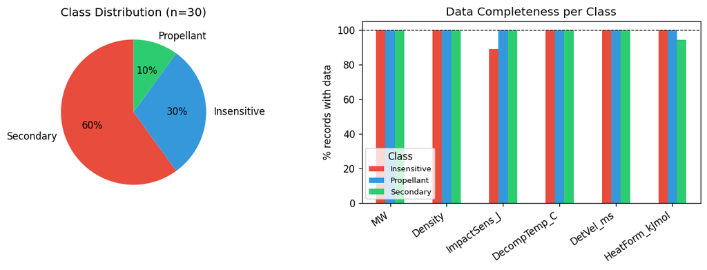

```python
# ── 1c: Class distribution and completeness per class ──────────

fig, axes = plt.subplots(1, 2, figsize=(11, 4))

# Pie chart — class distribution
class_counts = df['Class'].value_counts()
colors = ['#e74c3c','#3498db','#2ecc71','#f39c12']
axes[0].pie(class_counts, labels=class_counts.index, autopct='%1.0f%%',
            colors=colors, startangle=90)
axes[0].set_title('Class Distribution (n=30)')

# Stacked bar — data completeness per class
comp = df.groupby('Class')[numeric_cols].apply(lambda g: g.notna().mean() * 100)
comp.T.plot(kind='bar', ax=axes[1], color=colors)
axes[1].set_ylabel('% records with data')
axes[1].set_title('Data Completeness per Class')
axes[1].set_xticklabels(axes[1].get_xticklabels(), rotation=35, ha='right')
axes[1].legend(title='Class', fontsize=8)
axes[1].axhline(100, color='black', linestyle='--', linewidth=0.8)

plt.tight_layout()
plt.show()
```

## Block 2 · Structure Standardisation — Canonicalise and Deduplicate

When data comes from multiple papers:

- The same compound may appear under different names or with different SMILES strings
- Canonicalisation ensures every molecule has exactly one standard SMILES
- InChIKey comparison detects duplicate structures reliably

**Rule:** Always standardise SMILES before calculating any descriptors.

```python
# ── 2a: Validate and canonicalise all SMILES ───────────────────

from rdkit.Chem.inchi import MolToInchi, InchiToInchiKey

def standardise(smiles):
    """Return (canonical_smiles, inchikey) or (None, None) if invalid."""
    mol = MolFromSmiles(smiles)
    if mol is None:
        return None, None
    canon = MolToSmiles(mol)
    inchi = MolToInchi(mol)
    key   = InchiToInchiKey(inchi) if inchi else None
    return canon, key

df['CanonSMILES'], df['InChIKey'] = zip(*df['SMILES'].map(standardise))

n_invalid = df['CanonSMILES'].isna().sum()
print(f'Invalid SMILES: {n_invalid}')
print(f'Valid structures: {df["CanonSMILES"].notna().sum()}')

# Show original vs canonical for a few compounds
check = df[['Name','SMILES','CanonSMILES']].head(4).copy()
check['Changed?'] = check['SMILES'] != check['CanonSMILES']

display(check)
"""
display(check.style.hide(axis='index')
        .set_caption('Original vs Canonical SMILES')
        .set_table_styles([{'selector':'caption',
                            'props':[('font-size','14px'),('font-weight','bold')]}]))
"""
```

```
Invalid SMILES: 2
Valid structures: 28
```

[output not shown]

|  | Name | SMILES | CanonSMILES | Changed? |
| --- | --- | --- | --- | --- |
| 0 | TNT | Cc1c([N+](=O)[O-])cc([N+](=O)[O-])cc1[N+](=O)[O-] | Cc1c([N+](=O)[O-])cc([N+](=O)[O-])cc1[N+](=O)[O-] | False |
| 1 | RDX | O=[N+]([O-])N1CN([N+](=O)[O-])CN([N+](=O)[O-])C1 | O=[N+]([O-])N1CN([N+](=O)[O-])CN([N+](=O)[O-])C1 | False |
| 2 | HMX | O=[N+]([O-])N1CN([N+](=O)[O-])CN([N+](=O)[O-])... | O=[N+]([O-])N1CN([N+](=O)[O-])CN([N+](=O)[O-])... | False |
| 3 | PETN | C(CO[N+](=O)[O-])(CO[N+](=O)[O-])(CO[N+](=O)[O... | O=[N+]([O-])OCC(CO[N+](=O)[O-])(CO[N+](=O)[O-]... | True |

[output not shown]

```python
# ── 2b: Detect duplicates using InChIKey ───────────────────────

# Inject two known duplicates to demonstrate detection
dup_rows = pd.DataFrame([
    ['TNT-dup',   'O=[N+]([O-])c1cc([N+](=O)[O-])cc(C)c1[N+](=O)[O-]',  # different SMILES, same structure
     'C7H5N3O6', 227.13, 1.654, 15.0, 300, 6900, -54.4, 'Secondary', None, None],
    ['RDX-copy',  'O=[N+]([O-])N1CN([N+](=O)[O-])CN([N+](=O)[O-])C1',   # exact duplicate
     'C3H6N6O6', 222.12, 1.820,  7.4, 210, 8750,  86.3, 'Secondary', None, None],
], columns=df.columns)

# Standardise the injected rows
dup_rows['CanonSMILES'], dup_rows['InChIKey'] = zip(
    *dup_rows['SMILES'].map(standardise))

df_with_dups = pd.concat([df, dup_rows], ignore_index=True)
print(f'Dataset size before dedup: {len(df_with_dups)}')

# Find duplicates
dup_mask  = df_with_dups.duplicated(subset='InChIKey', keep='first')
dup_table = df_with_dups[df_with_dups['InChIKey'].duplicated(keep=False)][['Name','InChIKey','CanonSMILES']]

print(f'Duplicate entries found: {dup_mask.sum()}')
display(dup_table.sort_values('InChIKey'))
"""
display(dup_table.sort_values('InChIKey').style.hide(axis='index')
        .set_caption('Detected Duplicates (same InChIKey)')
        .set_table_styles([{'selector':'caption',
                            'props':[('font-size','14px'),('font-weight','bold')]}]))
"""


# Remove duplicates — keep first occurrence
df = df_with_dups[~dup_mask].reset_index(drop=True)
print(f'Dataset size after dedup:  {len(df)}')
```

```
Dataset size before dedup: 32
Duplicate entries found: 5
```

```
[18:16:18] WARNING: Charges were rearranged

[18:16:18] WARNING: Charges were rearranged
```

|  | Name | InChIKey | CanonSMILES |
| --- | --- | --- | --- |
| 22 | NG | ASIGVDLTBLZXNC-UHFFFAOYSA-N | O=[N+]([O-])OCC(O)CO[N+](=O)[O-] |
| 26 | MHN | ASIGVDLTBLZXNC-UHFFFAOYSA-N | O=[N+]([O-])OCC(O)CO[N+](=O)[O-] |
| 14 | BTNEU | BVKZIAODKDJPLW-UHFFFAOYSA-N | O=[N+]([O-])c1c([N+](=O)[O-])c([N+](=O)[O-])c(... |
| 17 | NONA | BVKZIAODKDJPLW-UHFFFAOYSA-N | O=[N+]([O-])c1c([N+](=O)[O-])c([N+](=O)[O-])c(... |
| 13 | Nitroguanidine | IDCPFAYURAQKDZ-UHFFFAOYSA-N | N=C(N)N[N+](=O)[O-] |
| 27 | NQ | IDCPFAYURAQKDZ-UHFFFAOYSA-N | N=C(N)N[N+](=O)[O-] |
| 1 | RDX | XTFIVUDBNACUBN-UHFFFAOYSA-N | O=[N+]([O-])N1CN([N+](=O)[O-])CN([N+](=O)[O-])C1 |
| 31 | RDX-copy | XTFIVUDBNACUBN-UHFFFAOYSA-N | O=[N+]([O-])N1CN([N+](=O)[O-])CN([N+](=O)[O-])C1 |
| 8 | CL-20 | None | None |
| 18 | BTF | None | None |

```
Dataset size after dedup:  27
```

## Block 3 · Explore the Dataset — Distributions and Correlations

Always **visualise your data** before building any model.  
Look for: skewed distributions, natural groupings, correlations between properties.

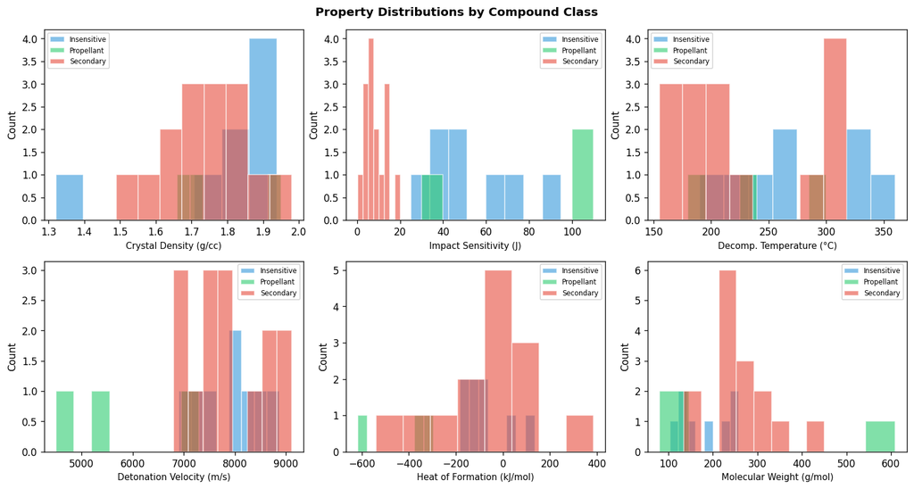

```python
# ── 3a: Property distribution histograms ──────────────────────

df_clean = df.dropna(subset=['InChIKey']).copy()

fig, axes = plt.subplots(2, 3, figsize=(13, 7))
axes = axes.flatten()

prop_labels = {
    'Density':       'Crystal Density (g/cc)',
    'ImpactSens_J':  'Impact Sensitivity (J)',
    'DecompTemp_C':  'Decomp. Temperature (°C)',
    'DetVel_ms':     'Detonation Velocity (m/s)',
    'HeatForm_kJmol':'Heat of Formation (kJ/mol)',
    'MW':            'Molecular Weight (g/mol)',
}
class_colors = {'Secondary':'#e74c3c','Insensitive':'#3498db',
                'Propellant':'#2ecc71'}

for ax, (col, label) in zip(axes, prop_labels.items()):
    for cls, grp in df_clean.groupby('Class'):
        vals = grp[col].dropna()
        if len(vals) > 1:
            ax.hist(vals, bins=8, alpha=0.6, label=cls,
                    color=class_colors.get(cls,'grey'), edgecolor='white')
    ax.set_xlabel(label, fontsize=9)
    ax.set_ylabel('Count')
    ax.legend(fontsize=7)

plt.suptitle('Property Distributions by Compound Class', fontsize=12, fontweight='bold')
plt.tight_layout()
plt.show()
```

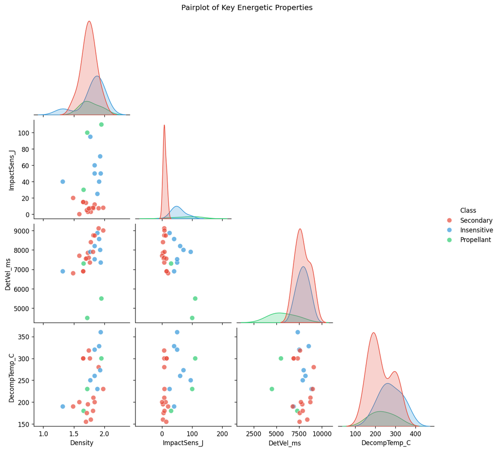

```
Diagonal: KDE of each property
Off-diagonal: scatter between pairs — look for linear or curved trends
```

```python
# ── 3b: Pairplot — density vs sensitivity vs det. velocity ─────

pair_cols = ['Density','ImpactSens_J','DetVel_ms','DecompTemp_C']
df_pair = df_clean[pair_cols + ['Class']].dropna()

g = sns.pairplot(df_pair, hue='Class',
                 palette={'Secondary':'#e74c3c','Insensitive':'#3498db',
                           'Propellant':'#2ecc71'},
                 diag_kind='kde', plot_kws={'alpha': 0.7, 's': 60},
                 corner=True)
g.figure.suptitle('Pairplot of Key Energetic Properties', y=1.01, fontsize=12)
plt.show()
print('Diagonal: KDE of each property')
print('Off-diagonal: scatter between pairs — look for linear or curved trends')
```

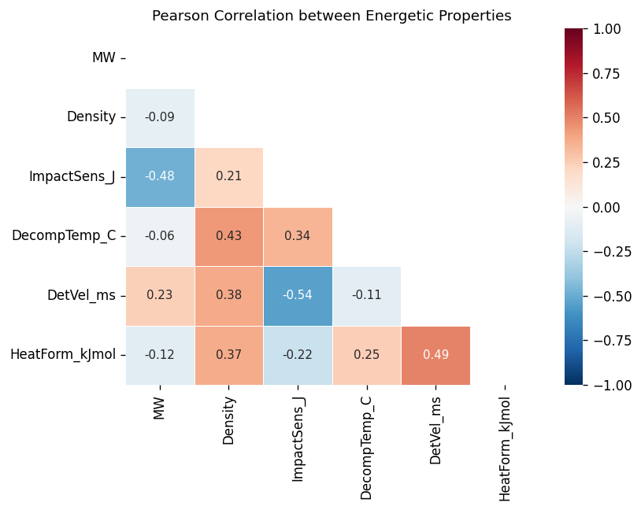

```
Strong positive (red) = both increase together
Strong negative (blue) = one increases as the other decreases
```

```python
# ── 3c: Correlation heatmap between properties ────────────────

corr = df_clean[numeric_cols].corr()

fig, ax = plt.subplots(figsize=(7, 5.5))
mask = np.triu(np.ones_like(corr, dtype=bool))   # show lower triangle only
sns.heatmap(corr, mask=mask, annot=True, fmt='.2f',
            cmap='RdBu_r', center=0, vmin=-1, vmax=1,
            linewidths=0.5, ax=ax, annot_kws={'size': 9})
ax.set_title('Pearson Correlation between Energetic Properties', fontsize=11)
plt.tight_layout()
plt.show()
print('Strong positive (red) = both increase together')
print('Strong negative (blue) = one increases as the other decreases')
```

## Block 4 · Detect and Handle Missing Values

Three strategies depending on how many values are missing:

| Strategy | When to use |
| --- | --- |
| **Drop rows** | Target property is missing — cannot use for training |
| **Drop columns** | >40% of values missing — descriptor is unreliable |
| **Impute (fill)** | <20% missing — replace with mean/median/mode |

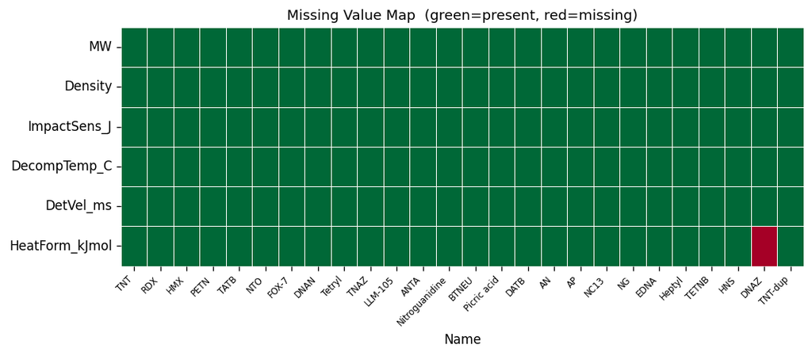

```python
# ── 4a: Visualise missing value pattern ───────────────────────

fig, ax = plt.subplots(figsize=(9, 4))
missing_matrix = df_clean[['Name'] + numeric_cols].set_index('Name').isna()
sns.heatmap(missing_matrix.T.astype(int), cmap='RdYlGn_r',
            linewidths=0.3, ax=ax, cbar=False,
            xticklabels=True, yticklabels=True)
ax.set_xticklabels(ax.get_xticklabels(), rotation=45, ha='right', fontsize=7)
ax.set_title('Missing Value Map  (green=present, red=missing)', fontsize=11)
plt.tight_layout()
plt.show()
```

```python
# ── 4b: Strategy 1 — drop rows where TARGET is missing ─────────
# Here the target is ImpactSens_J (impact sensitivity)

target = 'ImpactSens_J'
df_target = df_clean.dropna(subset=[target]).copy()

print(f'Rows before dropping missing target: {len(df_clean)}')
print(f'Rows after  dropping missing target: {len(df_target)}')
dropped = df_clean[df_clean[target].isna()]['Name'].tolist()
print(f'Dropped compounds: {dropped}')
```

```
Rows before dropping missing target: 26
Rows after  dropping missing target: 26
Dropped compounds: []
```

```python
# ── 4c: Strategy 2 — mean/median imputation for features ───────
# Impute HeatForm_kJmol (which has some missing values)

print('Before imputation:')
print(df_target[['Name','HeatForm_kJmol']].to_string(index=False))

imputer = SimpleImputer(strategy='median')   # 'mean', 'median', or 'most_frequent'
df_target[['HeatForm_kJmol']] = imputer.fit_transform(df_target[['HeatForm_kJmol']])

print(f'\nAfter median imputation: {df_target["HeatForm_kJmol"].isna().sum()} missing values remain')
print(f'Imputed median value used: {imputer.statistics_[0]:.2f} kJ/mol')
```

```
Before imputation:
          Name  HeatForm_kJmol
           TNT           -54.4
           RDX            86.3
           HMX            75.0
          PETN          -538.5
          TATB          -139.7
           NTO           -91.7
         FOX-7          -133.8
          DNAN          -182.7
        Tetryl            18.9
          TNAZ            17.0
       LLM-105           135.6
          ANTA            28.0
Nitroguanidine           -92.5
         BTNEU           385.0
   Picric acid          -217.8
          DATB          -143.5
            AN          -365.6
            AP          -295.8
          NC13          -618.0
            NG          -370.9
          EDNA          -148.0
        Heptyl          -136.0
         TETNB           125.0
           HNS            22.5
          DNAZ             NaN
       TNT-dup           -54.4

After median imputation: 0 missing values remain
Imputed median value used: -92.50 kJ/mol
```

```python
# ── 4d: Strategy 3 — KNN imputation (smarter, uses neighbours) ─

from sklearn.impute import KNNImputer

# Reintroduce missing values to demonstrate
df_knn = df_clean[numeric_cols].copy()
n_missing_before = df_knn.isna().sum().sum()

knn_imp = KNNImputer(n_neighbors=3)   # use 3 nearest compounds to fill gaps
df_knn_filled = pd.DataFrame(
    knn_imp.fit_transform(df_knn),
    columns=numeric_cols
)

print(f'Missing values before KNN imputation: {n_missing_before}')
print(f'Missing values after  KNN imputation: {df_knn_filled.isna().sum().sum()}')
print()
print('KNN imputer fills each gap using the average of the 3')
print('most similar rows in descriptor space — more realistic than mean imputation.')
```

```
Missing values before KNN imputation: 1
Missing values after  KNN imputation: 0

KNN imputer fills each gap using the average of the 3
most similar rows in descriptor space — more realistic than mean imputation.
```

## Block 5 · Detect and Handle Outliers

Outliers can be:

- **Real** — a genuinely extreme compound (do not delete without checking)
- **Errors** — transcription mistakes from papers (should be corrected)

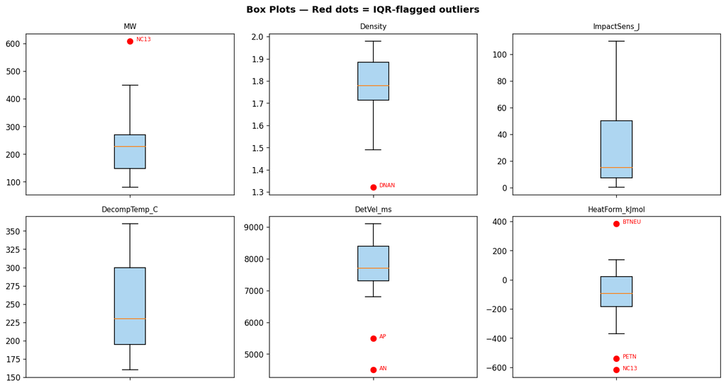

```python
# ── 5a: Box plots — visual outlier detection ──────────────────

df_plot = df_clean[numeric_cols].dropna()

fig, axes = plt.subplots(2, 3, figsize=(13, 7))
axes = axes.flatten()

for ax, col in zip(axes, numeric_cols):
    q1, q3 = df_plot[col].quantile([0.25, 0.75])
    iqr    = q3 - q1
    lo, hi = q1 - 1.5*iqr, q3 + 1.5*iqr
    outliers = df_clean[['Name', col]].dropna()
    outliers = outliers[(outliers[col] < lo) | (outliers[col] > hi)]

    ax.boxplot(df_plot[col].dropna(), vert=True, patch_artist=True,
               boxprops=dict(facecolor='#AED6F1'))
    # Overlay outlier labels
    for _, row in outliers.iterrows():
        ax.scatter(1, row[col], color='red', zorder=5, s=50)
        ax.annotate(row['Name'], (1, row[col]),
                    textcoords='offset points', xytext=(8, 0), fontsize=7, color='red')
    ax.set_title(col, fontsize=9)
    ax.set_xticklabels([])

plt.suptitle('Box Plots — Red dots = IQR-flagged outliers', fontsize=12, fontweight='bold')
plt.tight_layout()
plt.show()
```

```python
# ── 5b: Z-score outlier detection ─────────────────────────────

from scipy import stats as spstats

z_threshold = 2.5   # flag if |z| > 2.5

flagged_rows = []
for col in numeric_cols:
    subset = df_clean[['Name', col]].dropna()
    z      = np.abs(spstats.zscore(subset[col]))
    flagged = subset[z > z_threshold]
    for _, row in flagged.iterrows():
        flagged_rows.append({
            'Compound':  row['Name'],
            'Property':  col,
            'Value':     round(row[col], 2),
            '|Z-score|': round(z[z > z_threshold].iloc[
                list(flagged.index).index(row.name)], 2)
        })

df_flagged = pd.DataFrame(flagged_rows)
if df_flagged.empty:
    print('No outliers flagged at |Z| > 2.5')
else:
    display(df_flagged.sort_values('|Z-score|', ascending=False))
    """
        display(df_flagged.sort_values('|Z-score|', ascending=False)
            .style.hide(axis='index')
            .background_gradient(subset=['|Z-score|'], cmap='Reds')
            .set_caption(f'Z-score Outliers (threshold |Z| > {z_threshold})')
            .set_table_styles([{'selector':'caption',
                                'props':[('font-size','14px'),('font-weight','bold')]}]))
    """

    print()
    print('Action: go back to the original paper to verify each flagged value.')
    print('Do NOT delete automatically — some extremes are chemically real.')
```

|  | Compound | Property | Value | \|Z-score\| |
| --- | --- | --- | --- | --- |
| 0 | NC13 | MW | 609.21 | 3.37 |
| 2 | AN | DetVel_ms | 4500.00 | 3.08 |
| 1 | DNAN | Density | 1.32 | 3.02 |

```
Action: go back to the original paper to verify each flagged value.
Do NOT delete automatically — some extremes are chemically real.
```

```python
# ── 5c: Isolation Forest — ML-based multivariate outlier detection

from sklearn.ensemble import IsolationForest

df_iso = df_clean[numeric_cols].dropna()
names_iso = df_clean.loc[df_iso.index, 'Name'].values

iso = IsolationForest(contamination=0.1, random_state=42)  # expect ~10% outliers
labels = iso.fit_predict(df_iso)   # -1 = outlier, +1 = inlier
scores = iso.score_samples(df_iso)

iso_result = pd.DataFrame({
    'Compound': names_iso,
    'IsoScore': scores.round(4),
    'Label':    ['Outlier' if l == -1 else 'Inlier' for l in labels]
}).sort_values('IsoScore')

print(f'Isolation Forest results ({sum(labels==-1)} outliers flagged):')
"""
display(iso_result.style
        .applymap(lambda v: 'background-color:#ffcccc' if v=='Outlier' else '', subset=['Label'])
        .hide(axis='index')
        .set_caption('Isolation Forest Outlier Detection (lower score = more anomalous)')
        .set_table_styles([{'selector':'caption',
                            'props':[('font-size','14px'),('font-weight','bold')]}]))
"""
display(iso_result)
```

```
Isolation Forest results (3 outliers flagged):
```

|  | Compound | IsoScore | Label |
| --- | --- | --- | --- |
| 18 | NC13 | -0.5977 | Outlier |
| 16 | AN | -0.5975 | Outlier |
| 17 | AP | -0.5691 | Outlier |
| 13 | BTNEU | -0.5637 | Inlier |
| 3 | PETN | -0.5159 | Inlier |
| 7 | DNAN | -0.5060 | Inlier |
| 23 | HNS | -0.4895 | Inlier |
| 4 | TATB | -0.4785 | Inlier |
| 10 | LLM-105 | -0.4758 | Inlier |
| 12 | Nitroguanidine | -0.4722 | Inlier |
| 19 | NG | -0.4682 | Inlier |
| 2 | HMX | -0.4653 | Inlier |
| 21 | Heptyl | -0.4626 | Inlier |
| 11 | ANTA | -0.4569 | Inlier |
| 5 | NTO | -0.4513 | Inlier |
| 6 | FOX-7 | -0.4463 | Inlier |
| 20 | EDNA | -0.4358 | Inlier |
| 15 | DATB | -0.4248 | Inlier |
| 14 | Picric acid | -0.4203 | Inlier |
| 0 | TNT | -0.4180 | Inlier |
| 24 | TNT-dup | -0.4180 | Inlier |
| 22 | TETNB | -0.4168 | Inlier |
| 1 | RDX | -0.4159 | Inlier |
| 8 | Tetryl | -0.4158 | Inlier |
| 9 | TNAZ | -0.4102 | Inlier |

## Block 6 · Descriptor Calculation and Feature Matrix Assembly

Now we calculate **molecular descriptors** for every compound in the dataset  
and assemble the full feature matrix `X` paired with the target vector `y`.

We combine:

- **Zero-dimensional** descriptors (formula-based)
- **Two-dimensional** RDKit descriptors (topology)
- **Morgan fingerprint** bits (structural patterns)

```python
# ── 6a: Calculate descriptors for all valid compounds ──────────

fpgen = rdFingerprintGenerator.GetMorganGenerator(radius=2, fpSize=512)

def parse_formula(formula):
    counts = {}
    for elem in ['C','H','N','O']:
        m = re.search(rf'{elem}(\d*)', str(formula))
        counts[elem] = int(m.group(1)) if m and m.group(1) else (1 if m else 0)
    return counts

def calc_all_descriptors(name, smiles, formula, mw):
    """Returns a dict of descriptors for one compound."""
    mol = MolFromSmiles(smiles)
    if mol is None:
        return None

    e  = parse_formula(formula)
    ob = round((1600/mw)*(2*e['C']+e['H']/2-e['O']), 2) if mw else None

    # 0D
    d = {
        'Name':    name,
        'MW':      round(mw, 2),
        'nC':      e['C'], 'nH': e['H'], 'nN': e['N'], 'nO': e['O'],
        'nNO2':    smiles.count('[N+](=O)[O-]'),
        'NC_ratio':round(e['N']/e['C'], 3) if e['C'] else 0,
        'OB_pct':  ob,
    }

    # 2D RDKit
    d.update({
        'TPSA':       round(Descriptors.TPSA(mol), 2),
        'LogP':       round(Descriptors.MolLogP(mol), 3),
        'HBD':        rdMolDescriptors.CalcNumHBD(mol),
        'HBA':        rdMolDescriptors.CalcNumHBA(mol),
        'RotBonds':   rdMolDescriptors.CalcNumRotatableBonds(mol),
        'Rings':      rdMolDescriptors.CalcNumRings(mol),
        'ArRings':    rdMolDescriptors.CalcNumAromaticRings(mol),
        'HeavyAtoms': mol.GetNumHeavyAtoms(),
        'FrCSP3':     round(Descriptors.FractionCSP3(mol), 4),
        'BalabanJ':   round(Descriptors.BalabanJ(mol), 4),
        'Chi0':       round(Descriptors.Chi0(mol), 4),
        'Chi1':       round(Descriptors.Chi1(mol), 4),
        'Kappa1':     round(Descriptors.Kappa1(mol), 4),
    })

    # Morgan fingerprint bits (512-bit)
    fp  = fpgen.GetFingerprint(mol)
    arr = np.zeros(512, dtype=np.uint8)
    DataStructs.ConvertToNumpyArray(fp, arr)
    for i, bit in enumerate(arr):
        d[f'FP{i}'] = int(bit)

    return d

# Calculate for all compounds with valid SMILES
desc_rows = []
for _, row in df_target.iterrows():
    result = calc_all_descriptors(
        row['Name'], row['CanonSMILES'], row['Formula'], row['MW'])
    if result:
        result['ImpactSens_J']  = row['ImpactSens_J']
        result['Density']       = row['Density']
        result['DetVel_ms']     = row['DetVel_ms']
        result['Class']         = row['Class']
        desc_rows.append(result)

df_desc = pd.DataFrame(desc_rows)
print(f'Feature matrix assembled: {df_desc.shape}')
print(f'  {df_desc.shape[0]} compounds  ×  {df_desc.shape[1]} columns')
print(f'  (includes Name, targets, class + {512+13+9} descriptor columns)')
```

[output not shown]

```python
# ── 6b: Inspect descriptor matrix ─────────────────────────────

# Non-fingerprint descriptors only (easier to read)
meta_cols    = ['Name','ImpactSens_J','Density','DetVel_ms','Class']
struct_cols  = ['MW','nC','nH','nN','nO','nNO2','NC_ratio','OB_pct',
                'TPSA','LogP','HBD','HBA','RotBonds','Rings','ArRings',
                'HeavyAtoms','FrCSP3','BalabanJ','Chi0','Chi1','Kappa1']
display(df_desc[meta_cols + struct_cols].head(6))

"""
display(df_desc[meta_cols + struct_cols].head(6)
        .style.hide(axis='index')
        .format({c: '{:.2f}' for c in struct_cols if c not in ['nC','nH','nN','nO','nNO2','Rings','ArRings','HBD','HBA','RotBonds','HeavyAtoms']})
        .background_gradient(subset=['nNO2','OB_pct','TPSA'], cmap='YlOrRd')
        .set_caption('Descriptor Matrix — first 6 rows, structural descriptors only')
        .set_table_styles([{'selector':'caption',
                            'props':[('font-size','14px'),('font-weight','bold')]}]))
"""
```

|  | Name | ImpactSens_J | Density | DetVel_ms | Class | MW | nC | nH | nN | nO | ... | HBA | RotBonds | Rings | ArRings | HeavyAtoms | FrCSP3 | BalabanJ | Chi0 | Chi1 | Kappa1 |
| --- | --- | --- | --- | --- | --- | --- | --- | --- | --- | --- | --- | --- | --- | --- | --- | --- | --- | --- | --- | --- | --- |
| 0 | TNT | 15.0 | 1.654 | 6900 | Secondary | 227.13 | 7 | 5 | 3 | 6 | ... | 6 | 3 | 1 | 1 | 16 | 0.1429 | 3.5728 | 12.4557 | 7.3411 | 11.4945 |
| 1 | RDX | 7.4 | 1.820 | 8750 | Secondary | 222.12 | 3 | 6 | 6 | 6 | ... | 6 | 3 | 1 | 0 | 15 | 1.0000 | 2.7682 | 11.5854 | 6.9136 | 10.6794 |
| 2 | HMX | 7.4 | 1.905 | 9110 | Secondary | 296.16 | 4 | 8 | 8 | 8 | ... | 8 | 4 | 1 | 0 | 20 | 1.0000 | 3.0190 | 15.4472 | 9.2181 | 14.8595 |
| 3 | PETN | 3.0 | 1.778 | 8400 | Secondary | 316.14 | 5 | 8 | 4 | 12 | ... | 12 | 12 | 0 | 0 | 21 | 1.0000 | 5.0164 | 16.4663 | 9.6660 | 17.8000 |
| 4 | TATB | 50.0 | 1.939 | 7350 | Insensitive | 258.15 | 6 | 6 | 6 | 6 | ... | 9 | 3 | 1 | 1 | 18 | 0.0000 | 3.9384 | 14.1962 | 8.1962 | 12.8875 |
| 5 | NTO | 71.0 | 1.930 | 8000 | Insensitive | 130.06 | 2 | 2 | 4 | 3 | ... | 4 | 1 | 1 | 1 | 9 | 0.0000 | 3.1224 | 6.8534 | 4.1984 | 5.4762 |

6 rows × 26 columns

[output not shown]

## Block 7 · Feature Preprocessing — Filter, Correlation, Scaling

Raw descriptor matrices contain:

- **Constant or near-constant columns** (useless — remove)
- **Highly correlated pairs** (redundant — remove one)
- **Different scales** (unfair advantage — normalise)

This block walks through each step.

```python
# ── 7a: Separate feature matrix X and target y ────────────────

target_col  = 'ImpactSens_J'          # property we want to predict
drop_cols   = ['Name','ImpactSens_J','Density','DetVel_ms','Class']

X_raw = df_desc.drop(columns=drop_cols).astype(float)
y     = df_desc[target_col].astype(float)
names = df_desc['Name'].values

print(f'X shape (raw):  {X_raw.shape}  — {X_raw.shape[1]} features')
print(f'y shape:        {y.shape}')
```

```
X shape (raw):  (26, 533)  — 533 features
y shape:        (26,)
```

```python
# ── 7b: Step 1 — remove near-zero variance columns ─────────────

vt = VarianceThreshold(threshold=0.01)   # remove columns with variance < 0.01
X_vt = vt.fit_transform(X_raw)

removed_var = X_raw.shape[1] - X_vt.shape[1]
kept_cols   = X_raw.columns[vt.get_support()].tolist()

print(f'Before variance filter: {X_raw.shape[1]} features')
print(f'Removed (near-zero var): {removed_var}')
print(f'Remaining:               {X_vt.shape[1]}')

X_df = pd.DataFrame(X_vt, columns=kept_cols)
```

```
Before variance filter: 533 features
Removed (near-zero var): 331
Remaining:               202
```

```python
# ── 7c: Step 2 — remove highly correlated descriptor pairs ─────

def remove_high_corr(df_feat, threshold=0.90):
    """Remove one feature from each pair with |correlation| > threshold."""
    corr_mat = df_feat.corr().abs()
    upper    = corr_mat.where(np.triu(np.ones(corr_mat.shape), k=1).astype(bool))
    to_drop  = [col for col in upper.columns if any(upper[col] > threshold)]
    return df_feat.drop(columns=to_drop), to_drop

X_uncorr, dropped_corr = remove_high_corr(X_df, threshold=0.90)

print(f'After variance filter:    {X_df.shape[1]} features')
print(f'Removed (corr > 0.90):    {len(dropped_corr)}')
print(f'Remaining after both:     {X_uncorr.shape[1]}')
if dropped_corr:
    print(f'Example dropped: {dropped_corr[:5]}')
```

```
After variance filter:    202 features
Removed (corr > 0.90):    118
Remaining after both:     84
Example dropped: ['nO', 'TPSA', 'HBA', 'RotBonds', 'HeavyAtoms']
```

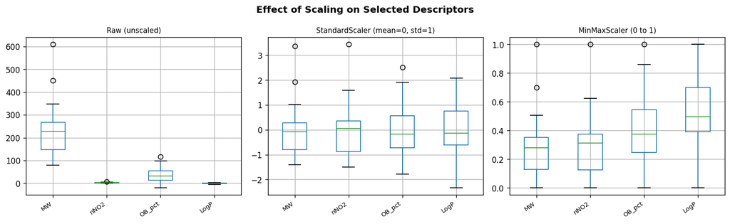

```
Final clean feature matrix: (26, 84)
```

```python
# ── 7d: Step 3 — scale features ────────────────────────────────

# StandardScaler: mean=0, std=1  (best for SVMs, neural networks)
# MinMaxScaler:   range [0, 1]   (good for tree models, visualisation)

scaler_std   = StandardScaler()
scaler_mm    = MinMaxScaler()

X_std = pd.DataFrame(scaler_std.fit_transform(X_uncorr),
                      columns=X_uncorr.columns)
X_mm  = pd.DataFrame(scaler_mm.fit_transform(X_uncorr),
                      columns=X_uncorr.columns)

# Compare raw vs scaled for a few key descriptors
compare_cols = [c for c in ['MW','TPSA','nNO2','OB_pct','LogP'] if c in X_uncorr.columns]

fig, axes = plt.subplots(1, 3, figsize=(13, 4))
for ax, (data, title) in zip(axes, [
    (X_uncorr[compare_cols], 'Raw (unscaled)'),
    (X_std[compare_cols],     'StandardScaler (mean=0, std=1)'),
    (X_mm[compare_cols],      'MinMaxScaler (0 to 1)'),
]):
    data.boxplot(ax=ax)
    ax.set_title(title, fontsize=9)
    ax.set_xticklabels(ax.get_xticklabels(), rotation=35, ha='right', fontsize=8)

plt.suptitle('Effect of Scaling on Selected Descriptors', fontsize=12, fontweight='bold')
plt.tight_layout()
plt.show()

print(f'Final clean feature matrix: {X_std.shape}')
```

## Block 8 · Train / Test Splitting — Random and Scaffold-Based

**The golden rule:** never evaluate a model on data it was trained on.

Two splitting strategies:

| Method | When to use | Pros / Cons |
| --- | --- | --- |
| **Random split** | Quick baseline | Fast; similar molecules may end up in both sets |
| **Scaffold split** | Realistic evaluation | Similar molecules stay together; harder test |

```
Random split (70/30)
  Training set: 18 compounds — ['HNS', 'NTO', 'HMX', 'Nitroguanidine', 'DATB', 'PETN', 'TATB', 'Heptyl', 'AP', 'TETNB', 'NC13', 'TNT-dup', 'EDNA', 'DNAN', 'LLM-105', 'Picric acid', 'NG', 'FOX-7']
  Test set:     8  compounds — ['Tetryl', 'AN', 'TNT', 'DNAZ', 'ANTA', 'TNAZ', 'BTNEU', 'RDX']
```

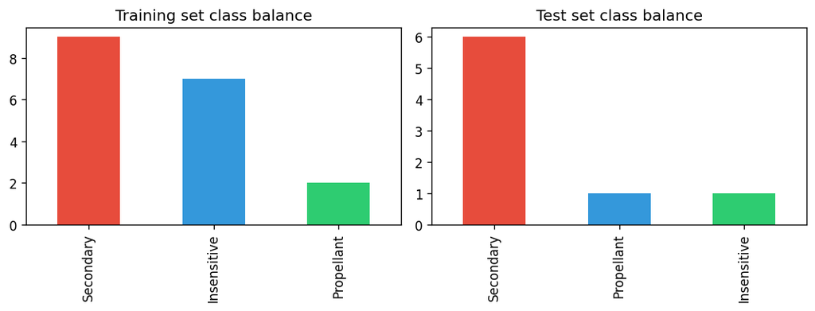

```python
# ── 8a: Simple random split (70 / 30) ─────────────────────────

X_train_r, X_test_r, y_train_r, y_test_r, names_train_r, names_test_r = \
    train_test_split(X_std, y, names,
                     test_size=0.30, random_state=42)

print('Random split (70/30)')
print(f'  Training set: {len(X_train_r)} compounds — {list(names_train_r)}')
print(f'  Test set:     {len(X_test_r)}  compounds — {list(names_test_r)}')

# Class balance check
cls_train = df_desc.set_index('Name').loc[names_train_r, 'Class'].value_counts()
cls_test  = df_desc.set_index('Name').loc[names_test_r,  'Class'].value_counts()

fig, axes = plt.subplots(1, 2, figsize=(9, 3.5))
cls_train.plot(kind='bar', ax=axes[0], color=['#e74c3c','#3498db','#2ecc71'])
axes[0].set_title('Training set class balance'); axes[0].set_xlabel('')
cls_test.plot(kind='bar',  ax=axes[1], color=['#e74c3c','#3498db','#2ecc71'])
axes[1].set_title('Test set class balance'); axes[1].set_xlabel('')
plt.tight_layout(); plt.show()
```

```python
# ── 8b: Scaffold-based split (keeps similar structures together)

def get_scaffold(smiles):
    """Return Murcko scaffold SMILES, or empty string for acyclics."""
    mol = MolFromSmiles(smiles)
    if mol is None:
        return ''
    try:
        scaffold = MurckoScaffold.GetScaffoldForMol(mol)
        return MolToSmiles(scaffold)
    except Exception:
        return ''

# Assign scaffold to each compound
df_scaffold = df_raw[['Name','SMILES']].copy()
df_scaffold.columns = ['Name','SMILES']
df_scaffold['Scaffold'] = df_scaffold['SMILES'].map(get_scaffold)

print('Scaffolds assigned:')

display(df_scaffold)

"""
display(df_scaffold.style.hide(axis='index')
        .set_caption('Murcko Scaffolds (empty = no ring system)')
        .set_table_styles([{'selector':'caption',
                            'props':[('font-size','14px'),('font-weight','bold')]}]))
"""
```

```
Scaffolds assigned:
```

```
[18:25:48] SMILES Parse Error: unclosed ring for input: 'O=[N+]([O-])N1CN2CN([N+](=O)[O-])CN1[N+](=O)[O-]'
[18:25:48] Can't kekulize mol.  Unkekulized atoms: 3 4 8 12 16
```

|  | Name | SMILES | Scaffold |
| --- | --- | --- | --- |
| 0 | TNT | Cc1c([N+](=O)[O-])cc([N+](=O)[O-])cc1[N+](=O)[O-] | c1ccccc1 |
| 1 | RDX | O=[N+]([O-])N1CN([N+](=O)[O-])CN([N+](=O)[O-])C1 | C1NCNCN1 |
| 2 | HMX | O=[N+]([O-])N1CN([N+](=O)[O-])CN([N+](=O)[O-])... | C1NCNCNCN1 |
| 3 | PETN | C(CO[N+](=O)[O-])(CO[N+](=O)[O-])(CO[N+](=O)[O... |  |
| 4 | TATB | Nc1c([N+](=O)[O-])c(N)c([N+](=O)[O-])c(N)c1[N+... | c1ccccc1 |
| 5 | NTO | O=[N+]([O-])c1n[nH]c(=O)[nH]1 | O=c1[nH]cn[nH]1 |
| 6 | FOX-7 | NC(=C([N+](=O)[O-])[N+](=O)[O-])N |  |
| 7 | DNAN | COc1ccc([N+](=O)[O-])cc1[N+](=O)[O-] | c1ccccc1 |
| 8 | CL-20 | O=[N+]([O-])N1CN2CN([N+](=O)[O-])CN1[N+](=O)[O-] |  |
| 9 | Tetryl | CN([N+](=O)[O-])c1c([N+](=O)[O-])cc([N+](=O)[O... | c1ccccc1 |
| 10 | TNAZ | O=[N+]([O-])C1(CN([N+](=O)[O-])C1[N+](=O)[O-])... | C1CNC1 |
| 11 | LLM-105 | Nc1nc2c([N+](=O)[O-])n[nH]c2c([N+](=O)[O-])n1 | c1ncc2[nH]ncc2n1 |
| 12 | ANTA | Nc1nnc([N+](=O)[O-])[nH]1 | c1nnc[nH]1 |
| 13 | Nitroguanidine | NC(=N)N[N+](=O)[O-] |  |
| 14 | BTNEU | O=[N+]([O-])c1c([N+](=O)[O-])c([N+](=O)[O-])c(... | c1ccccc1 |
| 15 | Picric acid | Oc1c([N+](=O)[O-])cc([N+](=O)[O-])cc1[N+](=O)[O-] | c1ccccc1 |
| 16 | DATB | Nc1c([N+](=O)[O-])c(N)c([N+](=O)[O-])cc1[N+](=... | c1ccccc1 |
| 17 | NONA | O=[N+]([O-])c1c([N+](=O)[O-])c([N+](=O)[O-])c(... | c1ccccc1 |
| 18 | BTF | O=[N+]([O-])c1c([N+](=O)[O-])c([N+](=O)[O-])c(... |  |
| 19 | AN | N.[N+](=O)([O-])[O-] |  |
| 20 | AP | [NH4+].[O-]Cl(=O)(=O)=O |  |
| 21 | NC13 | OCC1OC(OC2C(COC(=O)[N+](=O)[O-])OC(OC3C(COC(=O... | C1COCC(OC2CCC(OC3CCCO3)CO2)C1 |
| 22 | NG | O[C@@H](CO[N+](=O)[O-])CO[N+](=O)[O-] |  |
| 23 | EDNA | O=[N+]([O-])NCC[N+](=O)[O-] |  |
| 24 | Heptyl | CC(C)(C)c1c([N+](=O)[O-])cc([N+](=O)[O-])cc1[N... | c1ccccc1 |
| 25 | TETNB | O=[N+]([O-])c1c([N+](=O)[O-])c([N+](=O)[O-])cc... | c1ccccc1 |
| 26 | MHN | OC(CO[N+](=O)[O-])CO[N+](=O)[O-] |  |
| 27 | NQ | NC(=N)N[N+](=O)[O-] |  |
| 28 | HNS | O=[N+]([O-])c1ccc(C=Cc2ccc([N+](=O)[O-])cc2[N+... | C(=Cc1ccccc1)c1ccccc1 |
| 29 | DNAZ | O=[N+]([O-])N1CC([N+](=O)[O-])C1 | C1CNC1 |

[output not shown]

```python
# ── 8c: Assign train/test by scaffold (no scaffold shared) ─────

import random
random.seed(42)

scaffold_groups = df_scaffold.groupby('Scaffold')['Name'].apply(list).to_dict()
scaffold_list   = list(scaffold_groups.values())
random.shuffle(scaffold_list)

test_size_target = 0.30
total  = len(df_scaffold)
test_names, train_names = [], []

for group in scaffold_list:
    if len(test_names) / (total + 1e-9) < test_size_target:
        test_names.extend(group)
    else:
        train_names.extend(group)

# Remaining go to train
assigned = set(test_names + train_names)
for n in df_scaffold['Name']:
    if n not in assigned:
        train_names.append(n)

print(f'Scaffold split ({len(train_names)} train / {len(test_names)} test)')
print(f'  Train: {train_names}')
print(f'  Test:  {test_names}')

idx_map  = df_desc.set_index('Name').index
train_idx = [i for i, n in enumerate(df_desc['Name']) if n in train_names]
test_idx  = [i for i, n in enumerate(df_desc['Name']) if n in test_names]

X_train_s = X_std.iloc[train_idx]
X_test_s  = X_std.iloc[test_idx]
y_train_s = y.iloc[train_idx]
y_test_s  = y.iloc[test_idx]

print(f'\nActual split ratio — train: {len(X_train_s)/len(X_std):.1%},  '
      f'test: {len(X_test_s)/len(X_std):.1%}')
```

```
Scaffold split (20 train / 10 test)
  Train: ['NC13', 'TNAZ', 'DNAZ', 'LLM-105', 'HMX', 'NTO', 'ANTA', 'RDX', 'PETN', 'FOX-7', 'CL-20', 'Nitroguanidine', 'BTF', 'AN', 'AP', 'NG', 'EDNA', 'MHN', 'NQ', 'HNS']
  Test:  ['TNT', 'TATB', 'DNAN', 'Tetryl', 'BTNEU', 'Picric acid', 'DATB', 'NONA', 'Heptyl', 'TETNB']

Actual split ratio — train: 61.5%,  test: 34.6%
```

## Block 9 · Full Pipeline — SMILES to ML-Ready Matrix

This is what you would use as your **starting point** for any new dataset.

```python
# ── 9a: Complete pipeline function ────────────────────────────

def build_em_dataset(records, target_key='ImpactSens_J',
                     fp_bits=512, corr_threshold=0.90,
                     var_threshold=0.01, test_size=0.30,
                     random_state=42, scale='standard'):
    """
    records : list of dicts with keys Name, SMILES, Formula, MW, <target_key>, ...
    Returns : X_train, X_test, y_train, y_test, feature_names, scaler
    """
    fpgen = rdFingerprintGenerator.GetMorganGenerator(radius=2, fpSize=fp_bits)

    # ── Step 1: validate and canonicalise ──────────────────────
    valid = []
    for rec in records:
        mol = MolFromSmiles(rec['SMILES'])
        if mol is None or rec.get(target_key) is None:
            continue
        rec['CanonSMILES'] = MolToSmiles(mol)
        rec['mol']         = mol
        valid.append(rec)
    print(f'[1] Valid records with target: {len(valid)}')

    # ── Step 2: deduplicate by InChIKey ────────────────────────
    seen, deduped = set(), []
    for rec in valid:
        inchi = MolToInchi(rec['mol'])
        key   = InchiToInchiKey(inchi) if inchi else rec['CanonSMILES']
        if key not in seen:
            seen.add(key)
            deduped.append(rec)
    print(f'[2] After deduplication:        {len(deduped)}')

    # ── Step 3: calculate descriptors ─────────────────────────
    rows, targets, names_out = [], [], []
    for rec in deduped:
        mol = rec['mol']
        e   = parse_formula(rec.get('Formula',''))
        mw  = float(rec.get('MW', Descriptors.MolWt(mol)))
        ob  = round((1600/mw)*(2*e['C']+e['H']/2-e['O']), 2)

        d = {
            'nNO2':   rec['CanonSMILES'].count('[N+](=O)[O-]'),
            'nN':     e['N'], 'nO': e['O'], 'nC': e['C'],
            'MW':     mw, 'OB_pct': ob,
            'TPSA':   Descriptors.TPSA(mol),
            'LogP':   Descriptors.MolLogP(mol),
            'HBD':    rdMolDescriptors.CalcNumHBD(mol),
            'HBA':    rdMolDescriptors.CalcNumHBA(mol),
            'Rings':  rdMolDescriptors.CalcNumRings(mol),
            'FrCSP3': Descriptors.FractionCSP3(mol),
            'Chi0':   Descriptors.Chi0(mol),
            'Kappa1': Descriptors.Kappa1(mol),
        }
        fp  = fpgen.GetFingerprint(mol)
        arr = np.zeros(fp_bits, dtype=np.uint8)
        DataStructs.ConvertToNumpyArray(fp, arr)
        for i, bit in enumerate(arr):
            d[f'FP{i}'] = int(bit)

        rows.append(d)
        targets.append(float(rec[target_key]))
        names_out.append(rec['Name'])

    X_df = pd.DataFrame(rows)
    y_arr = np.array(targets)
    print(f'[3] Descriptor matrix:          {X_df.shape}')

    # ── Step 4: variance filter ────────────────────────────────
    vt = VarianceThreshold(threshold=var_threshold)
    X_vt = vt.fit_transform(X_df)
    feat_names = X_df.columns[vt.get_support()].tolist()
    print(f'[4] After variance filter:      {len(feat_names)} features')

    # ── Step 5: correlation filter ─────────────────────────────
    X_tmp  = pd.DataFrame(X_vt, columns=feat_names)
    X_unc, dropped = remove_high_corr(X_tmp, corr_threshold)
    print(f'[5] After correlation filter:   {X_unc.shape[1]} features')

    # ── Step 6: scale ──────────────────────────────────────────
    scaler = StandardScaler() if scale == 'standard' else MinMaxScaler()
    X_sc   = scaler.fit_transform(X_unc)

    # ── Step 7: train/test split ───────────────────────────────
    X_tr, X_te, y_tr, y_te, n_tr, n_te = train_test_split(
        X_sc, y_arr, names_out,
        test_size=test_size, random_state=random_state
    )
    print(f'[6] Train: {len(X_tr)}, Test: {len(X_te)}')
    print(f'    Train compounds: {list(n_tr)}')
    print(f'    Test  compounds: {list(n_te)}')

    return X_tr, X_te, y_tr, y_te, X_unc.columns.tolist(), scaler

print('Pipeline function defined. Run Block 9b to execute it.')
```

```
Pipeline function defined. Run Block 9b to execute it.
```

```python
# ── 9b: Run the pipeline on our dataset ───────────────────────

# Convert df_raw to list of dicts
records_in = df_raw.rename(columns={
    'ImpactSens_J': 'ImpactSens_J',
    'SMILES':       'SMILES',
    'Name':         'Name',
    'Formula':      'Formula',
    'MW':           'MW',
}).to_dict(orient='records')

X_train, X_test, y_train, y_test, feature_names, scaler = build_em_dataset(
    records_in,
    target_key='ImpactSens_J',
    fp_bits=256,
    corr_threshold=0.90,
    test_size=0.30
)

print(f'\nFinal arrays ready for ML:')
print(f'  X_train: {X_train.shape}  y_train: {y_train.shape}')
print(f'  X_test:  {X_test.shape}   y_test:  {y_test.shape}')
print(f'  Feature names (first 10): {feature_names[:10]}')
```

```
[1] Valid records with target: 28
[2] After deduplication:        25
[3] Descriptor matrix:          (25, 270)
[4] After variance filter:      163 features
[5] After correlation filter:   88 features
[6] Train: 17, Test: 8
    Train compounds: ['TETNB', 'NTO', 'HMX', 'Nitroguanidine', 'DATB', 'PETN', 'TATB', 'EDNA', 'AP', 'Heptyl', 'NC13', 'DNAZ', 'DNAN', 'LLM-105', 'Picric acid', 'NG', 'FOX-7']
    Test  compounds: ['Tetryl', 'AN', 'TNT', 'HNS', 'ANTA', 'TNAZ', 'BTNEU', 'RDX']

Final arrays ready for ML:
  X_train: (17, 88)  y_train: (17,)
  X_test:  (8, 88)   y_test:  (8,)
  Feature names (first 10): ['nNO2', 'nN', 'nO', 'nC', 'OB_pct', 'LogP', 'HBD', 'Rings', 'FrCSP3', 'FP0']
```

[output not shown]

```
Sanity check — Random Forest on cleaned dataset:
  R² training : 0.876
  R² test     : 0.728
  MAE test    : 14.23 J

Training R² >> Test R² means some overfitting — expected with n=20.
Larger datasets and cross-validation address this (see Chapter 4).
```

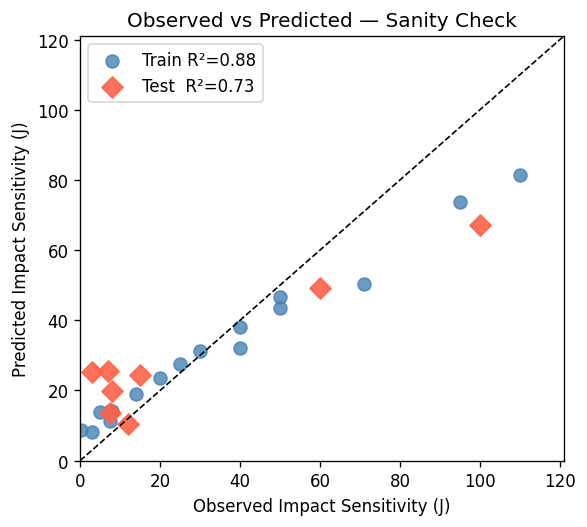

```python
# ── 9c: Quick sanity check — train a simple model ─────────────
# (Full modelling is covered in Chapter 4)

from sklearn.ensemble import RandomForestRegressor
from sklearn.metrics  import r2_score, mean_absolute_error

rf = RandomForestRegressor(n_estimators=100, random_state=42)
rf.fit(X_train, y_train)

y_pred_train = rf.predict(X_train)
y_pred_test  = rf.predict(X_test)

r2_train = r2_score(y_train, y_pred_train)
r2_test  = r2_score(y_test,  y_pred_test)
mae_test = mean_absolute_error(y_test, y_pred_test)

print(f'Sanity check — Random Forest on cleaned dataset:')
print(f'  R² training : {r2_train:.3f}')
print(f'  R² test     : {r2_test:.3f}')
print(f'  MAE test    : {mae_test:.2f} J')
print()
print('Training R² >> Test R² means some overfitting — expected with n=20.')
print('Larger datasets and cross-validation address this (see Chapter 4).')

# Observed vs predicted plot
fig, ax = plt.subplots(figsize=(5, 4.5))
ax.scatter(y_train, y_pred_train, color='steelblue', alpha=0.8,
           label=f'Train R²={r2_train:.2f}', s=60)
ax.scatter(y_test, y_pred_test, color='tomato', alpha=0.9,
           label=f'Test  R²={r2_test:.2f}',  s=80, marker='D')

lims = [0, df_desc['ImpactSens_J'].max()*1.1]
ax.plot(lims, lims, 'k--', linewidth=1)
ax.set_xlabel('Observed Impact Sensitivity (J)')
ax.set_ylabel('Predicted Impact Sensitivity (J)')
ax.set_title('Observed vs Predicted — Sanity Check')
ax.legend()
ax.set_xlim(lims); ax.set_ylim(lims)
plt.tight_layout()
plt.show()
```

## Summary — What You Learned in Chapter 3

| Block | Concept | Key Python tool |
| --- | --- | --- |
| 0 | Build a 30-compound literature dataset | `pandas.DataFrame` |
| 1 | Data quality audit — missing values, stats, class balance | `pd.isna`, `describe`, `matplotlib` |
| 2 | Canonicalise SMILES, detect duplicates via InChIKey | `MolToSmiles`, `InchiToInchiKey` |
| 3 | Visualise distributions, pairplots, correlations | `seaborn.pairplot`, `heatmap` |
| 4 | Handle missing values — drop, mean, KNN imputation | `SimpleImputer`, `KNNImputer` |
| 5 | Detect outliers — boxplot, Z-score, Isolation Forest | `scipy.stats.zscore`, `IsolationForest` |
| 6 | Calculate descriptors + fingerprints, assemble X matrix | `Descriptors`, `rdFingerprintGenerator` |
| 7 | Remove low-variance & correlated features; scale X | `VarianceThreshold`, `StandardScaler` |
| 8 | Random and scaffold-based train/test splits | `train_test_split`, `MurckoScaffold` |
| 9 | End-to-end pipeline: SMILES → ML-ready arrays | All of the above combined |

**Next →** Chapter 4: Training, tuning, and comparing QSPR models.

### References & Tools

- RDKit: https://www.rdkit.org/docs
- Scikit-learn preprocessing: https://scikit-learn.org/stable/modules/preprocessing.html
- Scikit-learn model selection: https://scikit-learn.org/stable/modules/model_evaluation.html
- Murcko scaffold splitting: https://www.rdkit.org/docs/source/rdkit.Chem.Scaffolds.MurckoScaffold.html
- Dobratz, B.M. *LLNL Explosives Reference Database*, 1981
- Cooper, P.W. *Explosives Engineering*, Wiley-VCH, 1996
- Zeman, S. *Sensitivities of High Energy Compounds*, Elsevier, 2003
- Karthikeyan & Vyas *Practical Chemoinformatics*, Springer, 2014